# DS2 Lab1 - H2O

Data Science 2: Machine Learning Tools - CEU 2021

Janos K. Divenyi, Jeno Pal

2021-02-24

H2O: state-of-the-art machine learning software that is even suitable for big datasets. It offers very efficient and scalable implementations of popular ML algorithms that can

- run on distributed systems
- utilize multiple cores
- work with GPUs

Models estimated with h2o can be deployed to production environments through Java objects (see [here](http://docs.h2o.ai/h2o/latest-stable/h2o-docs/productionizing.html)). Also, h2o scales well compared to other competitor implementations (see Szilard Pafka’s famous benchmarks [here](https://github.com/szilard/benchm-ml)).

In general, best resource to learn is the [documentation](http://docs.h2o.ai/h2o/latest-stable/h2o-docs/welcome.html) and many tutorials are available on YouTube.

```r
library(tidyverse)
library(ggplot2)

library(h2o)
h2o.init()
```

```
##  Connection successful!
##
## R is connected to the H2O cluster:
##     H2O cluster uptime:         21 hours 55 minutes
##     H2O cluster timezone:       Europe/Budapest
##     H2O data parsing timezone:  UTC
##     H2O cluster version:        3.32.0.4
##     H2O cluster version age:    24 days
##     H2O cluster name:           H2O_started_from_R_jdivenyi_crx271
##     H2O cluster total nodes:    1
##     H2O cluster total memory:   3.13 GB
##     H2O cluster total cores:    8
##     H2O cluster allowed cores:  8
##     H2O cluster healthy:        TRUE
##     H2O Connection ip:          localhost
##     H2O Connection port:        54321
##     H2O Connection proxy:       NA
##     H2O Internal Security:      FALSE
##     H2O API Extensions:         Amazon S3, XGBoost, Algos, AutoML, Core V3, TargetEncoder, Core V4
##     R Version:                  R version 4.0.3 (2020-10-10)
```

```r
# stop it via h2o.shutdown()
# you can specify how much memory H2O can use. If you have it, the more the better: h2o.init(max_mem_size = '8g')
```

```r
data <- as_tibble(ISLR::Wage)
data
```

| year | age | maritl | race | education | region | jobclass | health | health_ins | logwage | wage |
| --- | --- | --- | --- | --- | --- | --- | --- | --- | --- | --- |
| 2006 | 18 | 1. Never Married | 1. White | 1. < HS Grad | 2. Middle Atlantic | 1. Industrial | 1. <=Good | 2. No | 4.318063 | 75.04315 |
| 2004 | 24 | 1. Never Married | 1. White | 4. College Grad | 2. Middle Atlantic | 2. Information | 2. >=Very Good | 2. No | 4.255273 | 70.47602 |
| 2003 | 45 | 2. Married | 1. White | 3. Some College | 2. Middle Atlantic | 1. Industrial | 1. <=Good | 1. Yes | 4.875061 | 130.98218 |
| 2003 | 43 | 2. Married | 3. Asian | 4. College Grad | 2. Middle Atlantic | 2. Information | 2. >=Very Good | 1. Yes | 5.041393 | 154.68529 |
| 2005 | 50 | 4. Divorced | 1. White | 2. HS Grad | 2. Middle Atlantic | 2. Information | 1. <=Good | 1. Yes | 4.318063 | 75.04315 |
| 2008 | 54 | 2. Married | 1. White | 4. College Grad | 2. Middle Atlantic | 2. Information | 2. >=Very Good | 1. Yes | 4.845098 | 127.11574 |
| 2009 | 44 | 2. Married | 4. Other | 3. Some College | 2. Middle Atlantic | 1. Industrial | 2. >=Very Good | 1. Yes | 5.133021 | 169.52854 |
| 2008 | 30 | 1. Never Married | 3. Asian | 3. Some College | 2. Middle Atlantic | 2. Information | 1. <=Good | 1. Yes | 4.716003 | 111.72085 |
| 2006 | 41 | 1. Never Married | 2. Black | 3. Some College | 2. Middle Atlantic | 2. Information | 2. >=Very Good | 1. Yes | 4.778151 | 118.88436 |
| 2004 | 52 | 2. Married | 1. White | 2. HS Grad | 2. Middle Atlantic | 2. Information | 2. >=Very Good | 1. Yes | 4.857332 | 128.68049 |

[output cut: 2990 more lines]

```r
skimr::skim(data)
```

Data summary

| Name | data |
| --- | --- |
| Number of rows | 3000 |
| Number of columns | 11 |
| _______________________ |  |
| Column type frequency: |  |
| factor | 7 |
| numeric | 4 |
| ________________________ |  |
| Group variables | None |

**Variable type: factor**

| skim_variable | n_missing | complete_rate | ordered | n_unique | top_counts |
| --- | --- | --- | --- | --- | --- |
| maritl | 0 | 1 | FALSE | 5 | 2. : 2074, 1. : 648, 4. : 204, 5. : 55 |
| race | 0 | 1 | FALSE | 4 | 1. : 2480, 2. : 293, 3. : 190, 4. : 37 |
| education | 0 | 1 | FALSE | 5 | 2. : 971, 4. : 685, 3. : 650, 5. : 426 |
| region | 0 | 1 | FALSE | 1 | 2. : 3000, 1. : 0, 3. : 0, 4. : 0 |
| jobclass | 0 | 1 | FALSE | 2 | 1. : 1544, 2. : 1456 |
| health | 0 | 1 | FALSE | 2 | 2. : 2142, 1. : 858 |
| health_ins | 0 | 1 | FALSE | 2 | 1. : 2083, 2. : 917 |

**Variable type: numeric**

| skim_variable | n_missing | complete_rate | mean | sd | p0 | p25 | p50 | p75 | p100 | hist |
| --- | --- | --- | --- | --- | --- | --- | --- | --- | --- | --- |
| year | 0 | 1 | 2005.79 | 2.03 | 2003.00 | 2004.00 | 2006.00 | 2008.00 | 2009.00 | ▇▃▃▃▆ |
| age | 0 | 1 | 42.41 | 11.54 | 18.00 | 33.75 | 42.00 | 51.00 | 80.00 | ▃▇▇▃▁ |
| logwage | 0 | 1 | 4.65 | 0.35 | 3.00 | 4.45 | 4.65 | 4.86 | 5.76 | ▁▁▇▇▁ |
| wage | 0 | 1 | 111.70 | 41.73 | 20.09 | 85.38 | 104.92 | 128.68 | 318.34 | ▂▇▂▁▁ |

```r
data <- select(data, -c(region, wage))

h2o_data <- as.h2o(data)
str(h2o_data)
```

```
## Class 'H2OFrame' <environment: 0x7f9af241c7e8>
##  - attr(*, "op")= chr "Parse"
##  - attr(*, "id")= chr "data_sid_bddd_1"
##  - attr(*, "eval")= logi FALSE
##  - attr(*, "nrow")= int 3000
##  - attr(*, "ncol")= int 9
##  - attr(*, "types")=List of 9
##   ..$ : chr "int"
##   ..$ : chr "int"
##   ..$ : chr "enum"
##   ..$ : chr "enum"
##   ..$ : chr "enum"
##   ..$ : chr "enum"
##   ..$ : chr "enum"
##   ..$ : chr "enum"
##   ..$ : chr "real"
##  - attr(*, "data")='data.frame': 10 obs. of  9 variables:
##   ..$ year      : num  2006 2004 2003 2003 2005 ...
##   ..$ age       : num  18 24 45 43 50 54 44 30 41 52
##   ..$ maritl    : Factor w/ 5 levels "1. Never Married",..: 1 1 2 2 4 2 2 1 1 2
##   ..$ race      : Factor w/ 4 levels "1. White","2. Black",..: 1 1 1 3 1 1 4 3 2 1
##   ..$ education : Factor w/ 5 levels "1. < HS Grad",..: 1 4 3 4 2 4 3 3 3 2
##   ..$ jobclass  : Factor w/ 2 levels "1. Industrial",..: 1 2 1 2 2 2 1 2 2 2
##   ..$ health    : Factor w/ 2 levels "1. <=Good","2. >=Very Good": 1 2 1 2 1 2 2 1 2 2
##   ..$ health_ins: Factor w/ 2 levels "1. Yes","2. No": 2 2 1 1 1 1 1 1 1 1
##   ..$ logwage   : num  4.32 4.26 4.88 5.04 4.32 ...
```

```r
splitted_data <- h2o.splitFrame(h2o_data, ratios = c(0.6, 0.2), seed = 20210224)
data_train <- splitted_data[[1]]
data_valid <- splitted_data[[2]]
data_test <- splitted_data[[3]]
```

GLM: *penalized* linear regression methods.

```r
y <- "logwage"
X <- setdiff(names(h2o_data), c(y, "year"))

# alpha = 0 is the Ridge, just like we saw with glmnet
# lambda is determined by some heuristic
glm_fit <- h2o.glm(
  X, y,
  training_frame = data_train,
  alpha = 0, lambda = 0.0001,
  nfolds = 5,
  seed = 20210224
)
# xval stands for 'cross-validation'
print(h2o.performance(glm_fit, xval = TRUE))
```

```
## H2ORegressionMetrics: glm
## ** Reported on cross-validation data. **
## ** 5-fold cross-validation on training data (Metrics computed for combined holdout predictions) **
##
## MSE:  0.08014452
## RMSE:  0.2830981
## MAE:  0.2081751
## RMSLE:  0.050906
## Mean Residual Deviance :  0.08014452
## R^2 :  0.3505029
## Null Deviance :224.9558
## Null D.o.F. :1819
## Residual Deviance :145.863
## Residual D.o.F. :1798
## AIC :617.395
```

```r
print(h2o.rmse(glm_fit, xval = TRUE))
```

```
## [1] 0.2830981
```

You can perform a grid search with cross-validation to tune hyperparameters.

```r
hyper_params <- list(alpha = c(0, .25, .5, .75, 1))

# build grid search with previously selected hyperparameters
glm_grid <- h2o.grid(
  "glm", x = X, y = y,
  training_frame = data_train,
  lambda_search = TRUE,   # performs search for optimal lambda as well
  nfolds = 5,
  seed = 20210224,
  hyper_params = hyper_params
)
glm_grid
```

```
## H2O Grid Details
## ================
##
## Grid ID: Grid_GLM_RTMP_sid_bddd_3_model_R_1614181681571_24
## Used hyper parameters:
##   -  alpha
## Number of models: 5
## Number of failed models: 0
##
## Hyper-Parameter Search Summary: ordered by increasing residual_deviance
##    alpha                                                 model_ids
## 1  [0.0] Grid_GLM_RTMP_sid_bddd_3_model_R_1614181681571_24_model_1
## 2 [0.75] Grid_GLM_RTMP_sid_bddd_3_model_R_1614181681571_24_model_4
## 3  [0.5] Grid_GLM_RTMP_sid_bddd_3_model_R_1614181681571_24_model_3
## 4  [1.0] Grid_GLM_RTMP_sid_bddd_3_model_R_1614181681571_24_model_5
## 5 [0.25] Grid_GLM_RTMP_sid_bddd_3_model_R_1614181681571_24_model_2
##    residual_deviance
## 1 145.72614752507636
## 2 145.83725660921675
## 3 145.88566380305207
## 4 145.88584026948485
## 5 145.96165916668798
```

```r
# get the best model based on the cross-validation exercise
best_glm <- h2o.getModel(glm_grid@model_ids[[1]])
best_glm
```

```
## Model Details:
## ==============
##
## H2ORegressionModel: glm
## Model ID:  Grid_GLM_RTMP_sid_bddd_3_model_R_1614181681571_24_model_1
## GLM Model: summary
##     family     link              regularization
## 1 gaussian identity Ridge ( lambda = 0.005865 )
##                                                                    lambda_search
## 1 nlambda = 30, lambda.max = 7.4419, lambda.min = 0.005865, lambda.1se = 0.06349
##   number_of_predictors_total number_of_active_predictors number_of_iterations
## 1                         21                          21                   16
##    training_frame
## 1 RTMP_sid_bddd_3
##
## Coefficients: glm coefficients
##                     names coefficients standardized_coefficients
## 1               Intercept     4.452197                  4.547681
## 2 maritl.1. Never Married    -0.064850                 -0.064850
## 3       maritl.2. Married     0.087120                  0.087120
## 4       maritl.3. Widowed    -0.003657                 -0.003657
## 5      maritl.4. Divorced    -0.032834                 -0.032834
##
## ---
##                      names coefficients standardized_coefficients
## 17 jobclass.2. Information     0.008732                  0.008732
## 18        health.1. <=Good    -0.035564                 -0.035564
## 19   health.2. >=Very Good     0.028409                  0.028409
## 20       health_ins.1. Yes     0.098534                  0.098534
## 21        health_ins.2. No    -0.104511                 -0.104511
## 22                     age     0.002272                  0.026005
##
## H2ORegressionMetrics: glm
## ** Reported on training data. **
##
## MSE:  0.07808193
## RMSE:  0.2794314
## MAE:  0.2052893
## RMSLE:  0.0502336
## Mean Residual Deviance :  0.07808193
```

[output cut: 30 more lines]

```
## mse                     0.07982258 0.0052753547  0.08019606 0.072988085
## null_deviance             44.99117    4.6294003   49.868427   39.318172
## r2                      0.34873855  0.036954295    0.409783  0.31248364
## residual_deviance        29.081541    2.5445664   29.191364   26.640652
## rmse                    0.28240603  0.009314897   0.2831891  0.27016306
## rmsle                  0.050746616 0.0023905085 0.052173804 0.047120325
##                        cv_3_valid  cv_4_valid  cv_5_valid
## mae                     0.2090726  0.21042332  0.21029072
## mean_residual_deviance 0.07762095  0.08747804  0.08082973
## mse                    0.07762095  0.08747804  0.08082973
## null_deviance           42.077534   49.527817   44.163895
## r2                     0.34669614  0.32845578  0.34627426
## residual_deviance       27.477818   33.241657   28.856215
## rmse                   0.27860537   0.2957669   0.2843057
## rmsle                   0.0498419 0.053307466 0.051289584
```

```r
regularization_path <- h2o.getGLMFullRegularizationPath(best_glm)
cbind(
  lambda = regularization_path$lambdas,
  regularization_path$coefficients[, 1:6]
)
```

```
##            lambda maritl.1. Never Married maritl.2. Married maritl.3. Widowed
##  [1,] 7.441889124            -0.004705748       0.005637152     -2.816658e-05
##  [2,] 4.621539226            -0.007165358       0.008652849     -4.747923e-05
##  [3,] 2.870054157            -0.010632035       0.012987786     -8.008802e-05
##  [4,] 1.782352255            -0.015259508       0.018933069     -1.333110e-04
##  [5,] 1.106870947            -0.021043734       0.026628769     -2.146954e-04
##  [6,] 0.687385611            -0.027751303       0.035931446     -3.274503e-04
##  [7,] 0.426878110            -0.034893536       0.046306846     -4.650220e-04
##  [8,] 0.265098538            -0.041799362       0.056842373     -6.096900e-04
##  [9,] 0.164630684            -0.047820007       0.066465199     -7.404575e-04
## [10,] 0.102238444            -0.052589048       0.074305549     -8.501090e-04
## [11,] 0.063491806            -0.056158933       0.079978915     -9.620328e-04
## [12,] 0.039429487            -0.059209072       0.083237855     -1.217967e-03
## [13,] 0.024486379            -0.061199253       0.085388574     -1.541627e-03
## [14,] 0.015206456            -0.062822575       0.086402210     -2.094729e-03
```

[output cut: 25 more lines]

Random Forests are there for you to use as well.

```r
# here ntrees is also a tuning parameter
rf_params <- list(ntrees = c(10, 500), mtries = c(2, 3, 5))

rf_grid <- h2o.grid(
  "randomForest", x = X, y = y,
  training_frame = data_train,
  nfolds = 5,
  seed = 20210224,
  hyper_params = rf_params
)
rf_grid
```

```
## H2O Grid Details
## ================
##
## Grid ID: Grid_DRF_RTMP_sid_bddd_3_model_R_1614181681571_25
## Used hyper parameters:
##   -  mtries
##   -  ntrees
## Number of models: 6
## Number of failed models: 0
##
## Hyper-Parameter Search Summary: ordered by increasing residual_deviance
##   mtries ntrees                                                 model_ids
## 1      2    500 Grid_DRF_RTMP_sid_bddd_3_model_R_1614181681571_25_model_4
## 2      2     10 Grid_DRF_RTMP_sid_bddd_3_model_R_1614181681571_25_model_1
## 3      3    500 Grid_DRF_RTMP_sid_bddd_3_model_R_1614181681571_25_model_5
## 4      3     10 Grid_DRF_RTMP_sid_bddd_3_model_R_1614181681571_25_model_2
## 5      5    500 Grid_DRF_RTMP_sid_bddd_3_model_R_1614181681571_25_model_6
## 6      5     10 Grid_DRF_RTMP_sid_bddd_3_model_R_1614181681571_25_model_3
##     residual_deviance
## 1 0.08065738400968613
## 2 0.08323755784766838
## 3 0.08875693337518537
## 4 0.09405073775011995
## 5 0.09858633090421354
## 6  0.1043584256460944
```

```r
# get best models
glm_model <- h2o.getModel(glm_grid@model_ids[[1]])
rf_model <- h2o.getModel(rf_grid@model_ids[[1]])

# predict on validation set
validation_performances <- list(
  "glm" = h2o.rmse(h2o.performance(glm_model, newdata = data_valid)),
  "rf" = h2o.rmse(h2o.performance(rf_model, newdata = data_valid))
)

validation_performances
```

```
## $glm
## [1] 0.26517
##
## $rf
## [1] 0.2643387
```

```r
# test set performance
h2o.rmse(h2o.performance(rf_model, newdata = data_test))
```

```
## [1] 0.2919347
```

```r
# turn back h2oFrames to plain data.frame
prediction_vs_truth = bind_cols(
    as_tibble(h2o.predict(rf_model, newdata = data_test)),
    select(as_tibble(data_test), logwage)
)
prediction_vs_truth
```

| predict | logwage |
| --- | --- |
| 4.898717 | 4.845098 |
| 4.920132 | 4.903090 |
| 4.769112 | 4.505150 |
| 4.798083 | 4.861026 |
| 4.603199 | 4.591065 |
| 4.643834 | 4.431364 |
| 4.545047 | 4.755875 |
| 4.577966 | 3.544068 |
| 4.450912 | 4.397940 |
| 4.342451 | 4.193125 |

[output cut: 592 more lines]

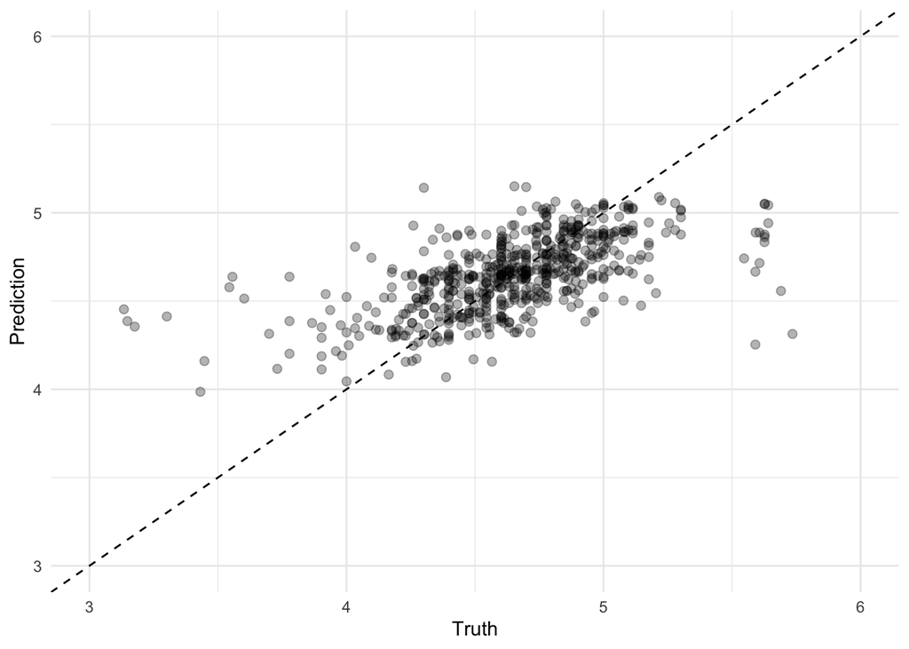

```r
ggplot(prediction_vs_truth, aes(logwage, predict)) +
  geom_abline(slope = 1, intercept = 0, linetype = "dashed") +
  xlim(3, 6) + ylim(3, 6) +
  geom_point(size = 2, alpha = 0.3) +
  theme_minimal() +
  labs(x = "Truth", y = "Prediction")
```

You might use H2O’s automl functionality that does the model search and hyperparameter tuning for you. You can use a lot of settings to limit the runtime or the number of tried models. You might also define a `leaderboard_frame` if you would like to calculate the performance metrics on a different data set instead of on the hold-out samples.

```r
automl_fit <- h2o.automl(
  X, y,
  training_frame = data_train,
  nfolds = 5,
  seed = 20210224
)
automl_fit@leaderboard
```

```
##                                              model_id mean_residual_deviance
## 1                        GBM_5_AutoML_20210225_144417             0.07736679
## 2 DeepLearning_grid__1_AutoML_20210225_144417_model_1             0.07737458
## 3          GBM_grid__1_AutoML_20210225_144417_model_4             0.07773489
## 4 DeepLearning_grid__2_AutoML_20210225_144417_model_1             0.07775786
## 5     XGBoost_grid__1_AutoML_20210225_144417_model_18             0.07782063
## 6          GBM_grid__1_AutoML_20210225_144417_model_5             0.07784512
##        rmse        mse       mae      rmsle
## 1 0.2781489 0.07736679 0.2040147 0.04999700
## 2 0.2781629 0.07737458 0.2038792 0.05003450
## 3 0.2788098 0.07773489 0.2047981 0.05010268
## 4 0.2788510 0.07775786 0.2045369 0.05012030
## 5 0.2789635 0.07782063 0.2060344 0.05010349
## 6 0.2790074 0.07784512 0.2048983 0.05015603
##
## [70 rows x 6 columns]
```

```r
# Compare the performance of the best model to our previous models
c(
  validation_performances,
  automl = h2o.rmse(h2o.performance(automl_fit@leader, data_valid))
)
```

```
## $glm
## [1] 0.26517
##
## $rf
## [1] 0.2643387
##
## $automl
## [1] 0.2603035
```

As you can see, there is some gain from using the auto-ML feature, but it does not change the big picture: each model gives us an RMSE of about 0.26. This corresponds to a mean absolute error of 0.19, meaning that we are off about 20% on average. To improve this performance, you probably need additional data instead of more sophisticated models.